# NYC Weather Data Preliminary EDA

Tejas Rawal

2022-10-26

# NYC Weather Data: Temperature analysis

```r
nyc_weather <- tibble(read.csv("../data/NYC_weather_1869_2022.csv")) %>%
  dplyr::select(TMAX, TMIN, DATE, PRCP, SNOW)
# view structure
str(nyc_weather)
```

```
## tibble [56,093 × 5] (S3: tbl_df/tbl/data.frame)
##  $ TMAX: int [1:56093] 25 26 36 43 44 35 36 26 38 46 ...
##  $ TMIN: int [1:56093] 17 4 19 28 19 11 20 20 26 32 ...
##  $ DATE: chr [1:56093] "1869-02-28" "1869-03-01" "1869-03-02" "1869-03-03" ...
##  $ PRCP: num [1:56093] 0 0 0.02 0 0.1 0 0.03 0 0 0 ...
##  $ SNOW: num [1:56093] 0 0 0 0 0 0 0.8 0 0 0 ...
```

```r
# get summary
xkablesummary(nyc_weather)
```

Table: Statistics summary.

|  | TMAX | TMIN | DATE | PRCP | SNOW |
| --- | --- | --- | --- | --- | --- |
| Min | Min. : 2.0 | Min. :-15.0 | Length:56093 | Min. :0.00 | Min. : 0.0 |
| Q1 | 1st Qu.: 46.0 | 1st Qu.: 34.0 | Class :character | 1st Qu.:0.00 | 1st Qu.: 0.0 |
| Median | Median : 63.0 | Median : 47.0 | Mode :character | Median :0.00 | Median : 0.0 |
| Mean | Mean : 61.5 | Mean : 46.8 | NA | Mean :0.12 | Mean : 0.1 |
| Q3 | 3rd Qu.: 78.0 | 3rd Qu.: 62.0 | NA | 3rd Qu.:0.05 | 3rd Qu.: 0.0 |
| Max | Max. :106.0 | Max. : 87.0 | NA | Max. :8.28 | Max. :27.3 |
| NA | NA’s :7 | NA’s :7 | NA | NA | NA’s :163 |

Convert DATE column from `char` to `Date` type

```r
nyc_weather <- nyc_weather %>%
  mutate(DATE = as.Date(DATE, format="%Y-%m-%d"))

# review dataset structure
xkablesummary(nyc_weather)
```

Table: Statistics summary.

|  | TMAX | TMIN | DATE | PRCP | SNOW |
| --- | --- | --- | --- | --- | --- |
| Min | Min. : 2.0 | Min. :-15.0 | Min. :1869-02-28 | Min. :0.00 | Min. : 0.0 |
| Q1 | 1st Qu.: 46.0 | 1st Qu.: 34.0 | 1st Qu.:1907-07-23 | 1st Qu.:0.00 | 1st Qu.: 0.0 |
| Median | Median : 63.0 | Median : 47.0 | Median :1945-12-13 | Median :0.00 | Median : 0.0 |
| Mean | Mean : 61.5 | Mean : 46.8 | Mean :1945-12-13 | Mean :0.12 | Mean : 0.1 |
| Q3 | 3rd Qu.: 78.0 | 3rd Qu.: 62.0 | 3rd Qu.:1984-05-05 | 3rd Qu.:0.05 | 3rd Qu.: 0.0 |
| Max | Max. :106.0 | Max. : 87.0 | Max. :2022-09-26 | Max. :8.28 | Max. :27.3 |
| NA | NA’s :7 | NA’s :7 | NA | NA | NA’s :163 |

Add a MONTH column to the dataset. The month is extracted from the DATE.  
Subset data for DATE > 1900

```r
nyc_weather <- nyc_weather %>%
  filter(lubridate::year(DATE) >= 1900) %>%
  mutate(MONTH = lubridate::month(DATE, label=T))

str(nyc_weather)
```

```
## tibble [44,829 × 6] (S3: tbl_df/tbl/data.frame)
##  $ TMAX : int [1:44829] 20 23 26 32 39 40 43 40 33 41 ...
##  $ TMIN : int [1:44829] 14 13 19 19 29 32 31 20 15 30 ...
##  $ DATE : Date[1:44829], format: "1900-01-01" "1900-01-02" ...
##  $ PRCP : num [1:44829] 0.03 0 0 0 0 0 0 0.01 0 0 ...
##  $ SNOW : num [1:44829] 0.5 0 0 0 0 0 0 0 0 0 ...
##  $ MONTH: Ord.factor w/ 12 levels "Jan"<"Feb"<"Mar"<..: 1 1 1 1 1 1 1 1 1 1 ...
```

```r
# review dataset structure
xkablesummary(nyc_weather)
```

Table: Statistics summary.

|  | TMAX | TMIN | DATE | PRCP | SNOW | MONTH |
| --- | --- | --- | --- | --- | --- | --- |
| Min | Min. : 2.0 | Min. :-15.0 | Min. :1900-01-01 | Min. :0.00 | Min. : 0.0 | Jan : 3813 |
| Q1 | 1st Qu.: 47.0 | 1st Qu.: 34.0 | 1st Qu.:1930-09-08 | 1st Qu.:0.00 | 1st Qu.: 0.0 | Mar : 3813 |
| Median | Median : 63.0 | Median : 48.0 | Median :1961-05-15 | Median :0.00 | Median : 0.0 | May : 3813 |
| Mean | Mean : 62.1 | Mean : 47.2 | Mean :1961-05-15 | Mean :0.13 | Mean : 0.1 | Jul : 3813 |
| Q3 | 3rd Qu.: 78.0 | 3rd Qu.: 62.0 | 3rd Qu.:1992-01-20 | 3rd Qu.:0.05 | 3rd Qu.: 0.0 | Aug : 3813 |
| Max | Max. :106.0 | Max. : 87.0 | Max. :2022-09-26 | Max. :7.57 | Max. :27.3 | Oct : 3782 |
| NA | NA | NA | NA | NA | NA’s :96 | (Other):21982 |

### Temperature Plots

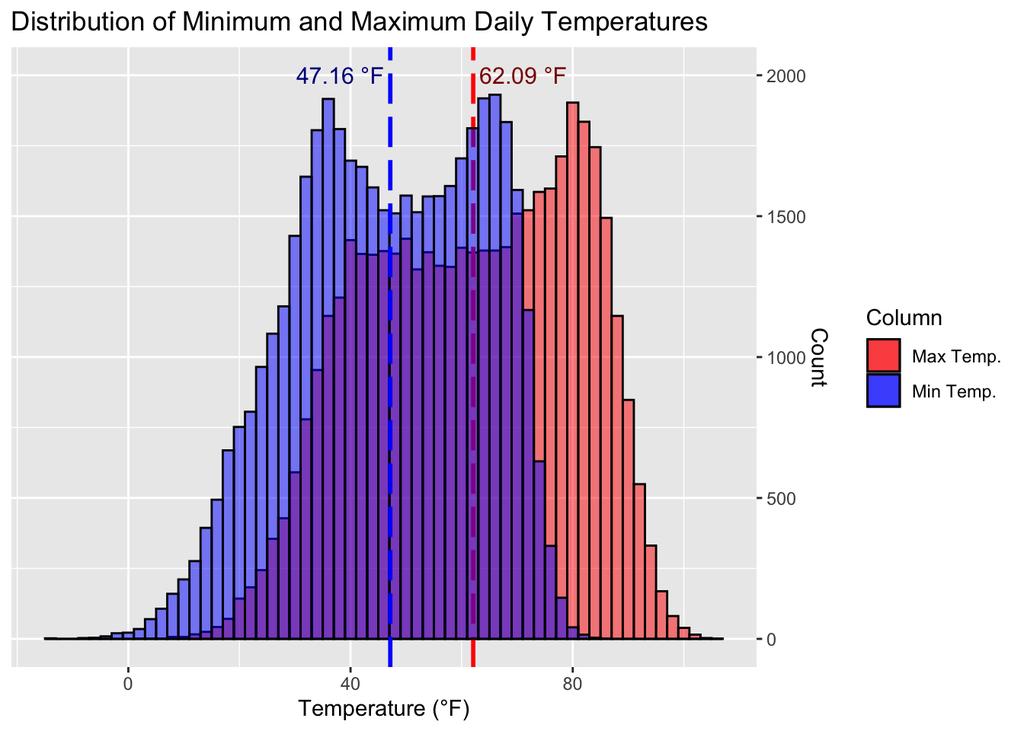

```r
mean_tmax <- mean(nyc_weather$TMAX)
mean_tmin <- mean(nyc_weather$TMIN)

ggplot(nyc_weather) +
  geom_histogram(aes(x=TMAX, fill="Max Temp."), na.rm=TRUE, alpha=0.5, color="black", bins=100, binwidth=2) +
  geom_vline(xintercept=mean_tmax, color="red", size=1, linetype=5, show.legend=FALSE) +
  annotate("text", x=mean_tmax + 9, y=2000, label=paste(round(mean_tmax, 2), "°F" ), angle=0, size=4, color="darkred") +
  geom_histogram(aes(x=TMIN, fill="Min Temp."), na.rm=TRUE, alpha=0.5, color="black", bins=100, binwidth=2) +
  geom_vline(xintercept=mean_tmin, color="blue", size=1, linetype=5, show.legend=FALSE) +
  annotate("text", x=mean_tmin - 9, y=2000, label=paste(round(mean_tmin, 2), "°F" ), angle=0, size=4, color="darkblue") +
  labs(title="Distribution of Minimum and Maximum Daily Temperatures", x="Temperature (°F)", y="Count") +
  scale_y_continuous(position = "right") +
  scale_fill_manual(name="Column", values=c("Max Temp."="red","Min Temp."="blue"))
```

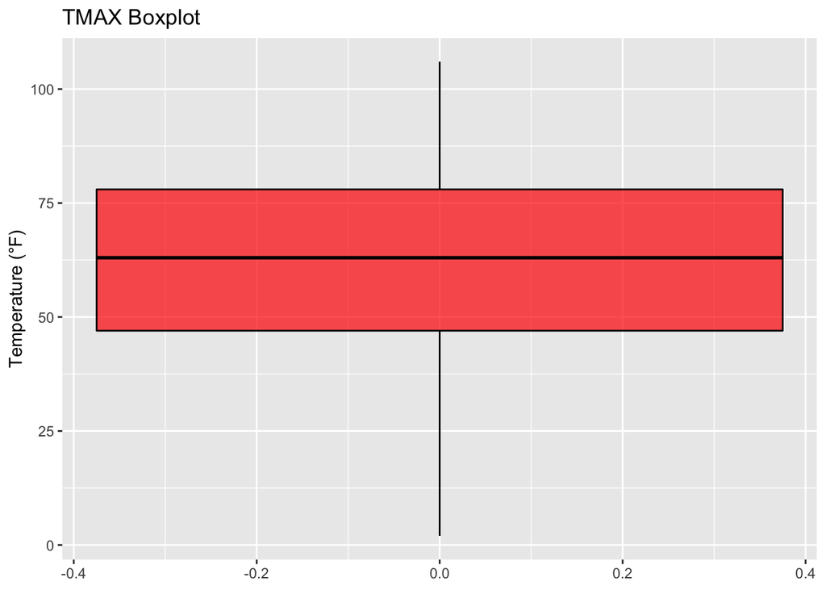

```r
nyc_weather %>%
  ggplot(aes(y=TMAX)) +
  geom_boxplot(na.rm=TRUE, alpha=0.7, color="black", fill="red") +
  labs(title="TMAX Boxplot", y="Temperature (°F)")
```

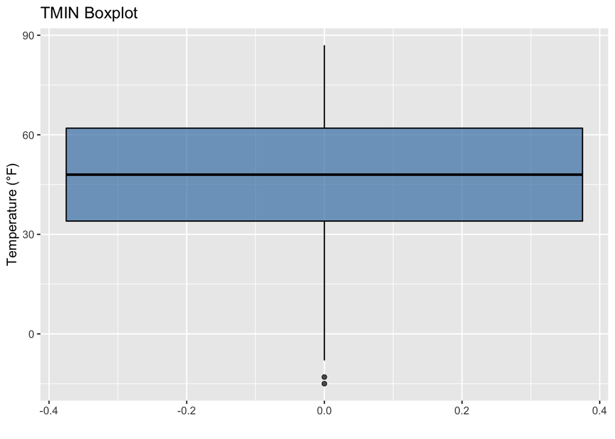

```r
nyc_weather %>%
  ggplot(aes(y=TMIN)) +
  geom_boxplot(na.rm=TRUE, alpha=0.7, color="black", fill="steelblue") +
  labs(title="TMIN Boxplot", x="", y="Temperature (°F)")
```

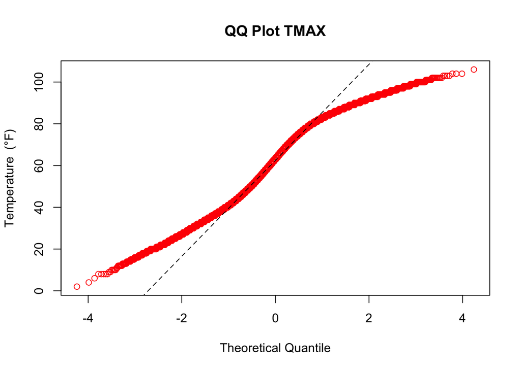

```r
qqnorm(nyc_weather$TMAX,
       main="QQ Plot TMAX",
       xlab="Theoretical Quantile",
       ylab="Temperature  (°F)",
       col="red")
qqline(nyc_weather$TMAX, lwd=1, lty=2)
```

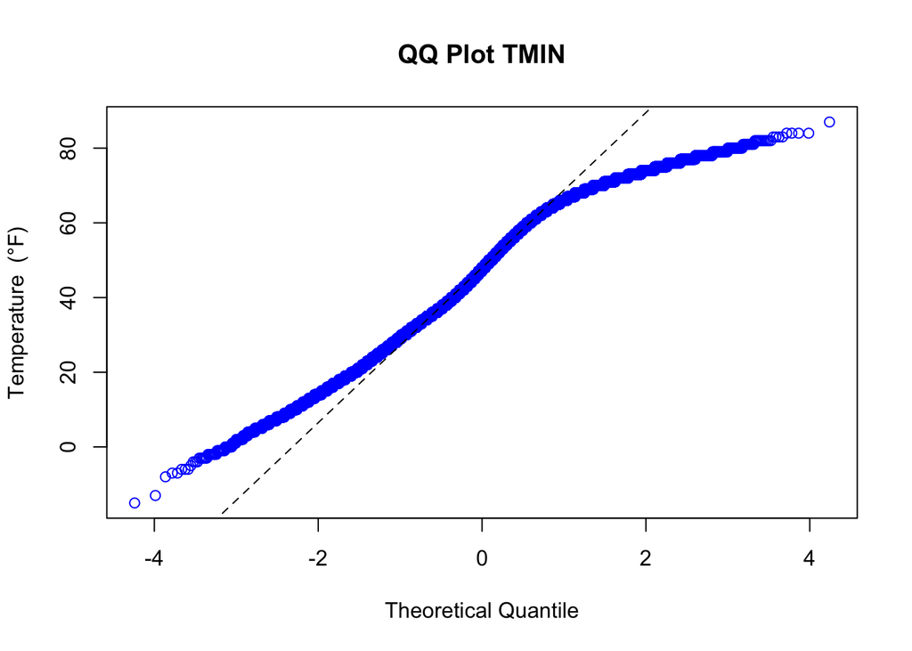

```r
qqnorm(nyc_weather$TMIN,
       main="QQ Plot TMIN",
       xlab="Theoretical Quantile",
       ylab="Temperature  (°F)",
       col="blue")
qqline(nyc_weather$TMIN, lwd=1, lty=2)
```

### Average daily temperature max and min by month, all time

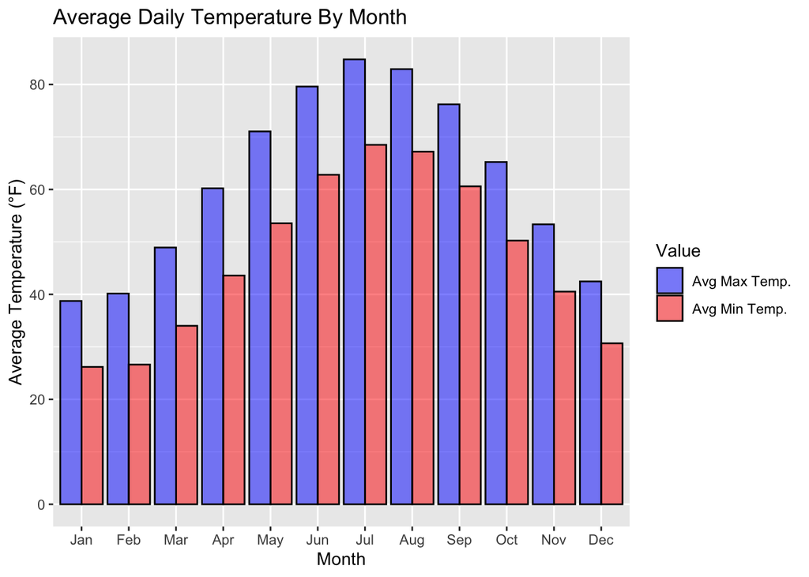

```r
# group data by month
# and calculate average
nyc_weather_by_month <- nyc_weather %>%
  group_by(MONTH) %>%
  summarize("Avg Max Temp." = mean(TMAX, na.rm=T),
            "Avg Min Temp." = mean(TMIN, na.rm=T),
            avg_prcp = mean(PRCP, na.rm=T),
            avg_snow = mean(SNOW, na.rm=T))

# side-by-side bar plot
nyc_weather_by_month %>%
  dplyr::select(MONTH, "Avg Max Temp.", "Avg Min Temp.") %>%
  gather(key="Value", value="Temp.", "Avg Max Temp.", "Avg Min Temp.") %>%
  ggplot(aes(x=MONTH, y=Temp., fill=Value)) +
  geom_col(na.rm=TRUE, alpha=0.5, color="black", position="dodge") +
  labs(title="Average Daily Temperature By Month", x="Month", y="Average Temperature (°F)") +
  scale_fill_manual(values=c("blue", "red"))
```

### Average percipitation and snow fall by month, all time

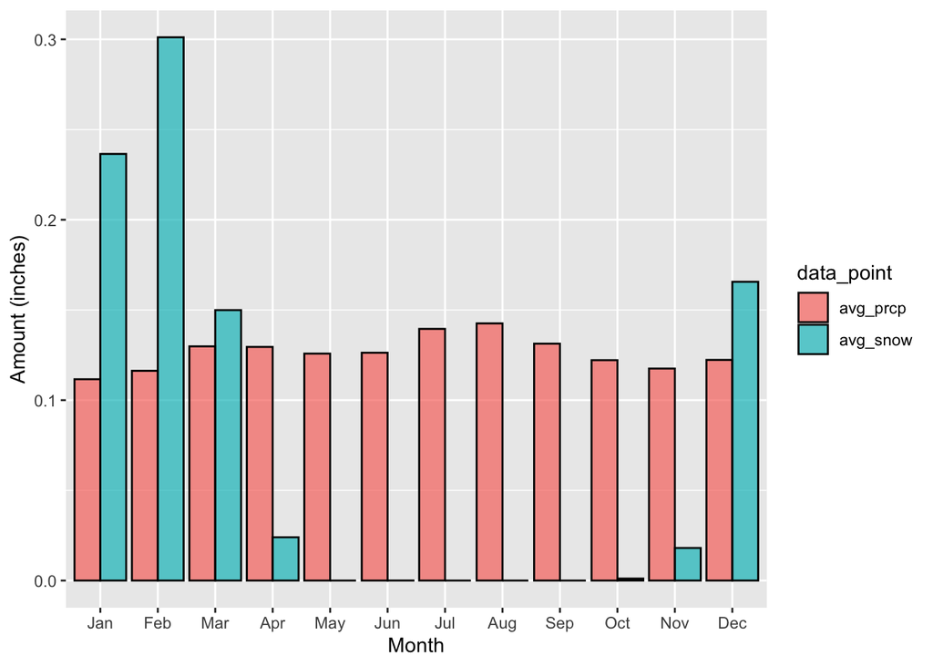

```r
nyc_weather_by_month %>%
  dplyr::select(MONTH, avg_prcp, avg_snow) %>%
  gather(key = "data_point", value="value", avg_prcp, avg_snow) %>%
  ggplot(aes(x=MONTH, y=value, fill=data_point)) +
    geom_col(na.rm=TRUE, alpha=0.7, color="black", position="dodge") +
    labs(x="Month", y="Amount (inches)")
```

## Categorical Analysis

For this analysis, I sought to subset the data into 30-50 year periods as such:  
* 1900-1940: Industrial Revolution  
* 1940-1980: Cold War Era  
* 1980-present: Modern Era

### 1900-1940

#### Temperature and Precipitation Boxplots

```r
# filter weather data for years 1900-1940
industrial_era <- nyc_weather %>%
  dplyr::select(-MONTH) %>%
  filter(lubridate::year(DATE) >= 1900, lubridate::year(DATE) < 1940)

str(industrial_era)
```

```
## tibble [14,609 × 5] (S3: tbl_df/tbl/data.frame)
##  $ TMAX: int [1:14609] 20 23 26 32 39 40 43 40 33 41 ...
##  $ TMIN: int [1:14609] 14 13 19 19 29 32 31 20 15 30 ...
##  $ DATE: Date[1:14609], format: "1900-01-01" "1900-01-02" ...
##  $ PRCP: num [1:14609] 0.03 0 0 0 0 0 0 0.01 0 0 ...
##  $ SNOW: num [1:14609] 0.5 0 0 0 0 0 0 0 0 0 ...
```

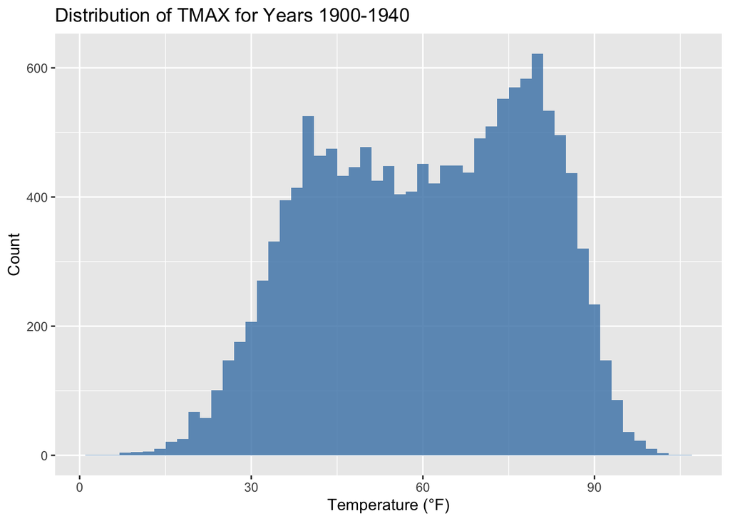

```r
industrial_era %>%
  ggplot() +
  geom_histogram(aes(x=TMAX, fill="TMAX"), na.rm=TRUE, alpha=0.8, fill="steelblue", bins=100, binwidth=2) +
  labs(title="Distribution of TMAX for Years 1900-1940", x="Temperature (°F)", y="Count")
```

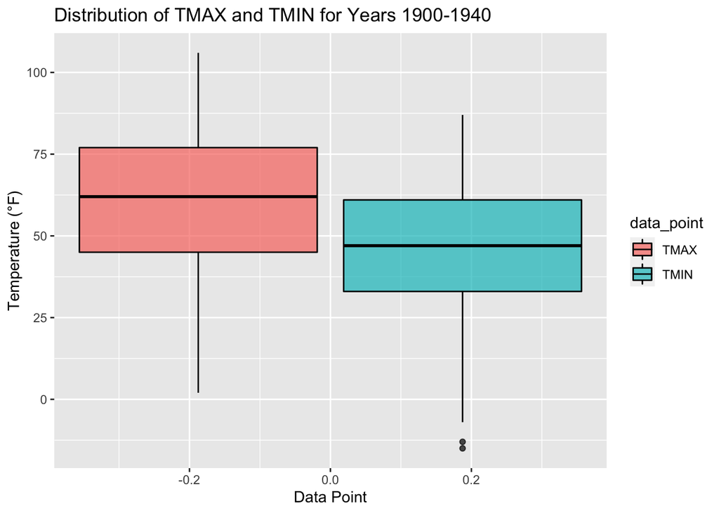

```r
industrial_era %>%
  dplyr::select(TMAX, TMIN, DATE) %>%
  gather(key="data_point", value="value", TMAX, TMIN) %>%
  ggplot(aes(y=value, fill=data_point)) +
  geom_boxplot(na.rm=TRUE, alpha=0.7, color="black") +
  labs(title="Distribution of TMAX and TMIN for Years 1900-1940", x="Data Point", y="Temperature (°F)")
```

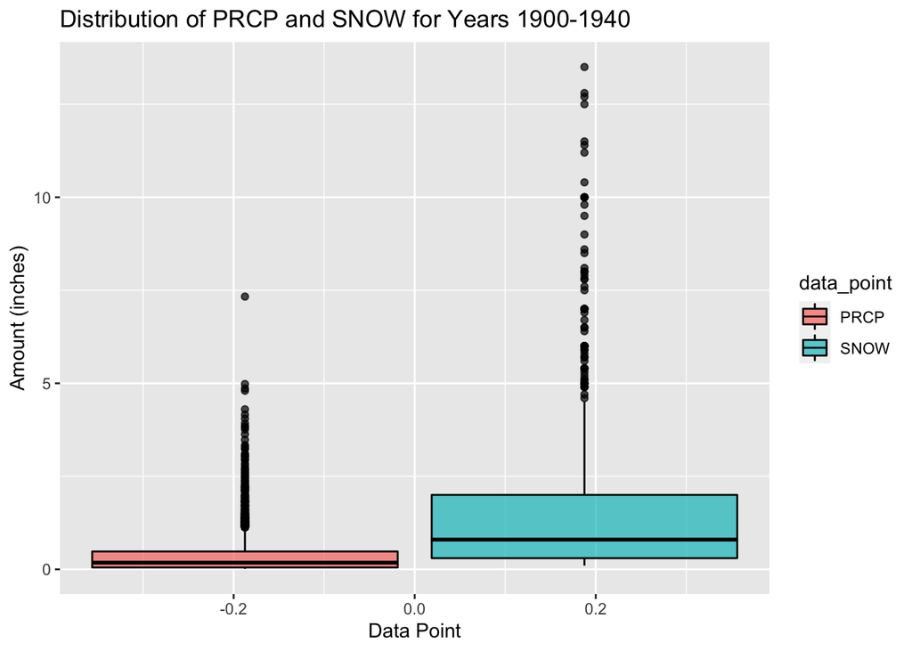

```r
industrial_era %>%
  dplyr::select(PRCP, SNOW, DATE) %>%
  gather(key="data_point", value="value", PRCP, SNOW) %>%
  filter(value > 0.0) %>%
  ggplot(aes(y=value, fill=data_point)) +
  geom_boxplot(na.rm=TRUE, alpha=0.7, color="black") +
  labs(title="Distribution of PRCP and SNOW for Years 1900-1940", x="Data Point", y="Amount (inches)")
```

### 1940-1980

#### Temperature and Precipitation Boxplots

```r
coldwar_era <- nyc_weather %>%
  dplyr::select(-MONTH) %>%
  filter(lubridate::year(DATE) >= 1940, lubridate::year(DATE) < 1980)

str(coldwar_era)
```

```
## tibble [14,610 × 5] (S3: tbl_df/tbl/data.frame)
##  $ TMAX: int [1:14610] 24 28 33 32 29 30 26 24 29 34 ...
##  $ TMIN: int [1:14610] 15 17 17 20 16 14 12 19 20 18 ...
##  $ DATE: Date[1:14610], format: "1940-01-01" "1940-01-02" ...
##  $ PRCP: num [1:14610] 0 0 0 0 0.03 0 0 0.08 0 0 ...
##  $ SNOW: num [1:14610] 0 0 0 0 0.3 0 0 1 0 0 ...
```

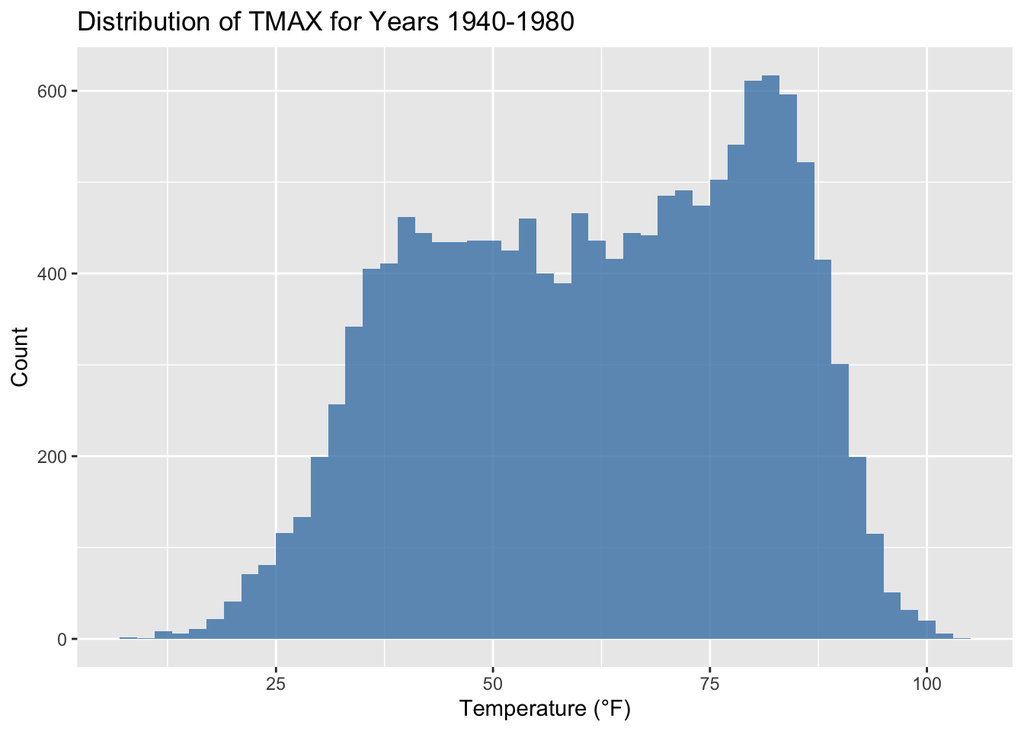

```r
coldwar_era %>%
  ggplot() +
  geom_histogram(aes(x=TMAX, fill="TMAX"), na.rm=TRUE, alpha=0.8, fill="steelblue", bins=100, binwidth=2) +
  labs(title="Distribution of TMAX for Years 1940-1980", x="Temperature (°F)", y="Count")
```

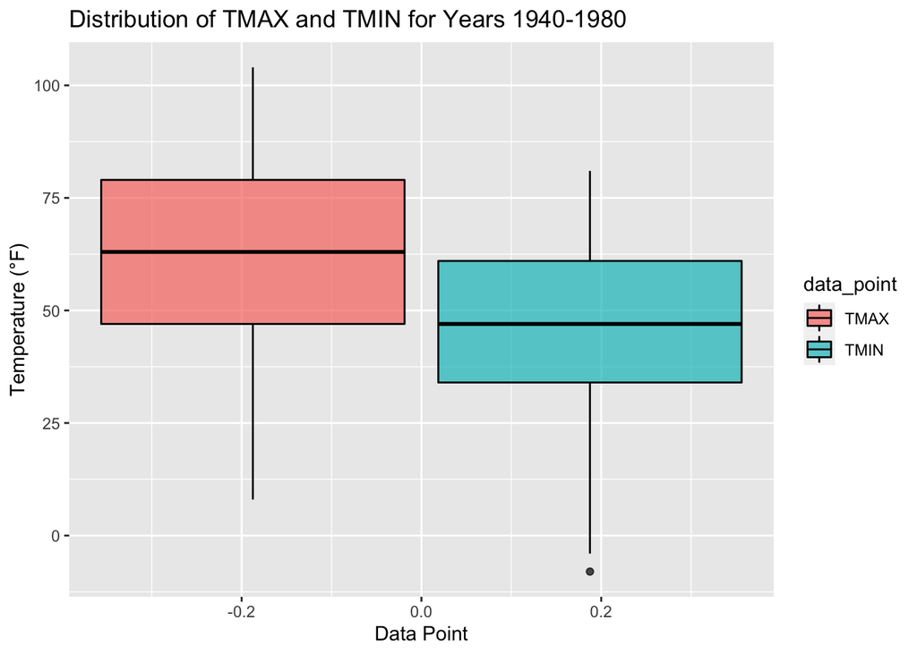

```r
coldwar_era %>%
  dplyr::select(TMAX, TMIN, DATE) %>%
  gather(key="data_point", value="value", TMAX, TMIN) %>%
  ggplot(aes(y=value, fill=data_point)) +
  geom_boxplot(na.rm=TRUE, alpha=0.7, color="black") +
  labs(title="Distribution of TMAX and TMIN for Years 1940-1980", x="Data Point", y="Temperature (°F)")
```

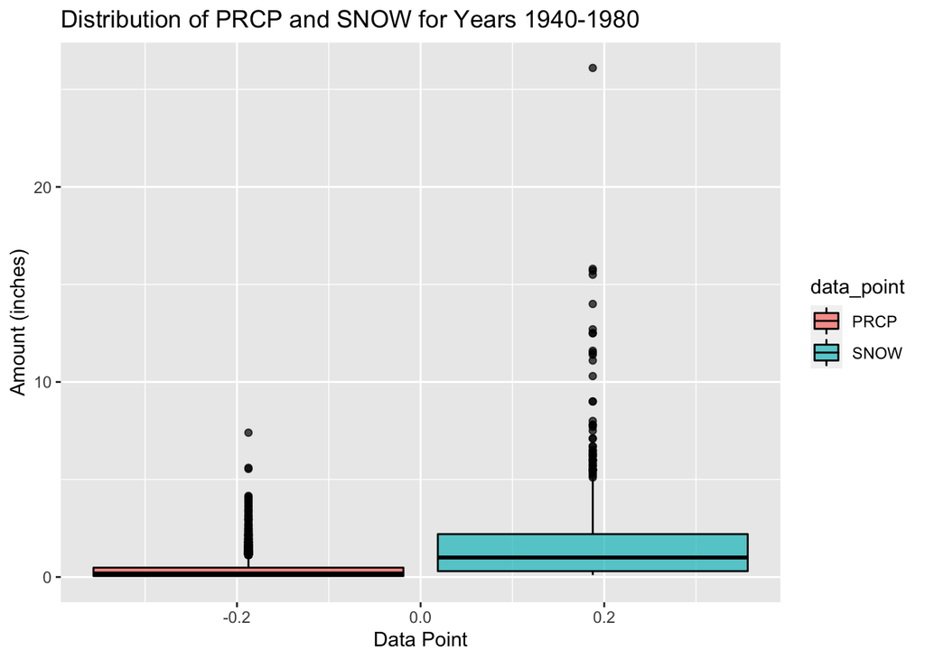

```r
coldwar_era %>%
  dplyr::select(PRCP, SNOW, DATE) %>%
  gather(key="data_point", value="value", PRCP, SNOW) %>%
  filter(value > 0.0) %>%
  ggplot(aes(y=value, fill=data_point)) +
  geom_boxplot(na.rm=TRUE, alpha=0.7, color="black") +
  labs(title="Distribution of PRCP and SNOW for Years 1940-1980", x="Data Point", y="Amount (inches)")
```

### 1980 - present

#### Temperature and Precipitation Boxplots

```r
modern_era <- nyc_weather %>%
  dplyr::select(-MONTH) %>%
  filter(lubridate::year(DATE) >= 1980)

str(modern_era)
```

```
## tibble [15,610 × 5] (S3: tbl_df/tbl/data.frame)
##  $ TMAX: int [1:15610] 45 42 38 30 32 32 40 38 32 34 ...
##  $ TMIN: int [1:15610] 34 34 28 21 26 19 27 31 29 23 ...
##  $ DATE: Date[1:15610], format: "1980-01-01" "1980-01-02" ...
##  $ PRCP: num [1:15610] 0 0 0 0 0.07 0 0 0 0 0 ...
##  $ SNOW: num [1:15610] 0 0 0 0 2 0 0 0 0 0 ...
```

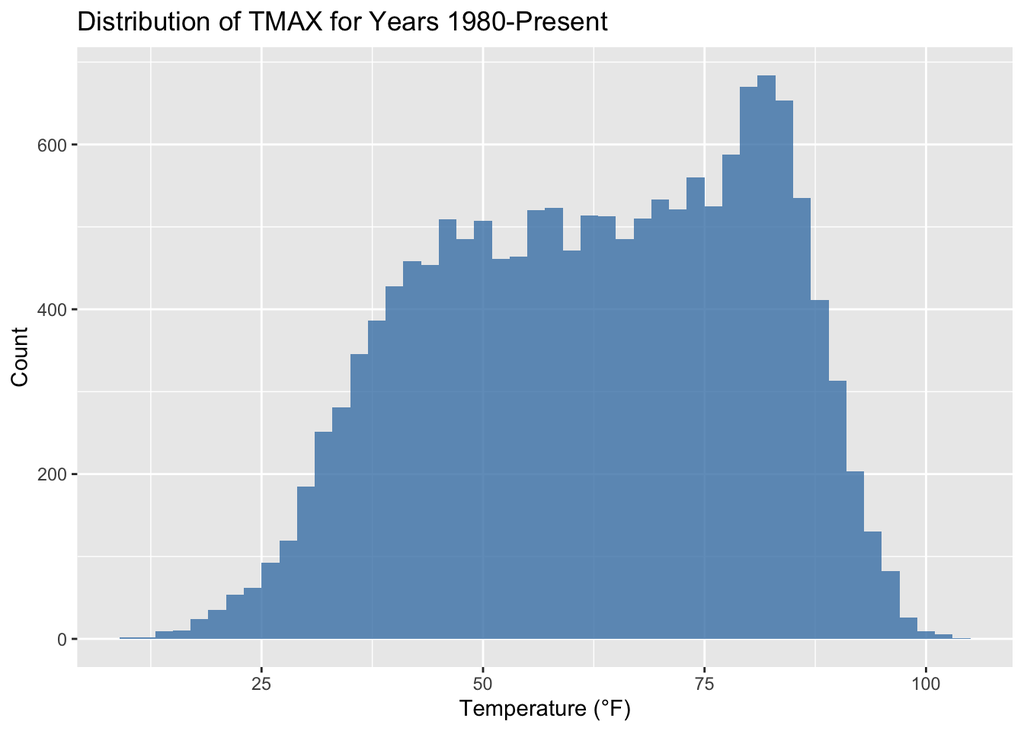

```r
modern_era %>%
  ggplot() +
  geom_histogram(aes(x=TMAX, fill="TMAX"), na.rm=TRUE, alpha=0.8, fill="steelblue", bins=100, binwidth=2) +
  labs(title="Distribution of TMAX for Years 1980-Present", x="Temperature (°F)", y="Count")
```

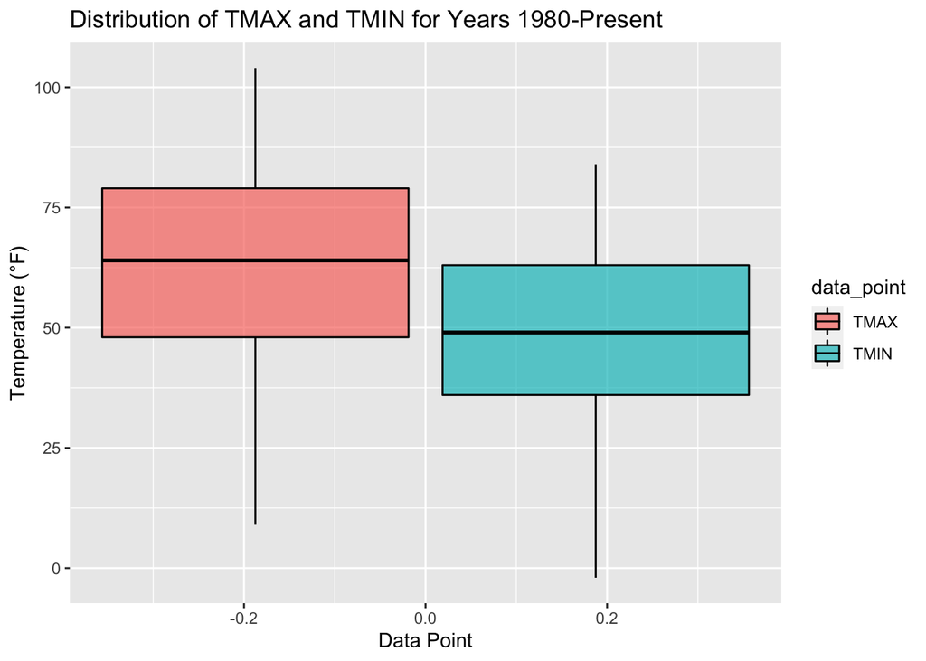

```r
modern_era %>%
  dplyr::select(TMAX, TMIN, DATE) %>%
  gather(key="data_point", value="value", TMAX, TMIN) %>%
  ggplot(aes(y=value, fill=data_point)) +
  geom_boxplot(na.rm=TRUE, alpha=0.7, color="black") +
  labs(title="Distribution of TMAX and TMIN for Years 1980-Present", x="Data Point", y="Temperature (°F)")
```

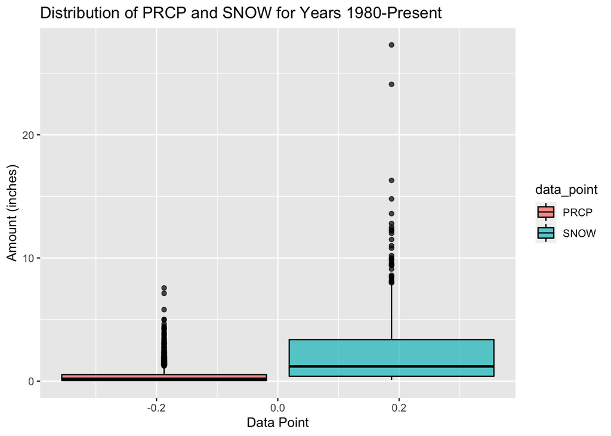

```r
modern_era %>%
  dplyr::select(PRCP, SNOW, DATE) %>%
  gather(key="data_point", value="value", PRCP, SNOW) %>%
  filter(value > 0.0) %>%
  ggplot(aes(y=value, fill=data_point)) +
  geom_boxplot(na.rm=TRUE, alpha=0.7, color="black") +
  labs(title="Distribution of PRCP and SNOW for Years 1980-Present", x="Data Point", y="Amount (inches)")
```

### ANOVA test

#### Mean TMAX by era

```r
industrial_avg_tmax <- mean(industrial_era$TMAX)
coldwar_avg_tmax <- mean(coldwar_era$TMAX)
modern_avg_tmax <- mean(modern_era$TMAX)

industrial_avg_tmax
```

```
## [1] 60.9
```

```r
coldwar_avg_tmax
```

```
## [1] 62.2
```

```r
modern_avg_tmax
```

```
## [1] 63.1
```

We can see above that there is an increase in average daily temperature max over the three eras. $H_0:$ The average `TMAX` across the three eras is equal.  
$H_1:$ The average `TMAX` across the three eras is different.  
$\alpha$: `0.05`

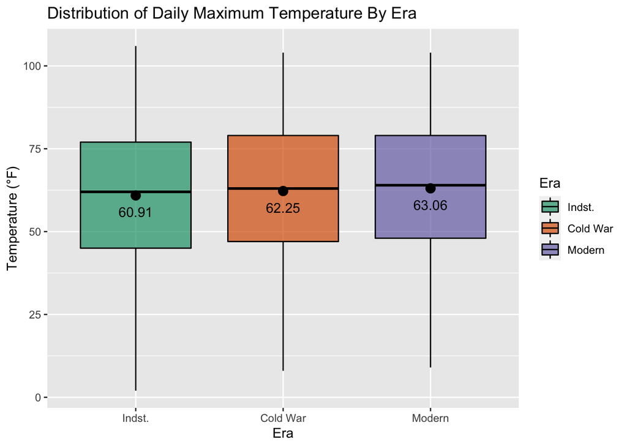

```r
# modify data set by adding ERA column
industrial_era <- industrial_era %>%
  mutate(Era = 1)
coldwar_era <- coldwar_era %>%
  mutate(Era = 2)
modern_era <- modern_era %>%
  mutate(Era = 3)
# combine data frames
all_eras <- rbind(industrial_era, coldwar_era, modern_era)
# convert ERA column to factor/categorical
all_eras$Era <- factor(all_eras$Era, labels = c("Indst.", "Cold War", "Modern"))

# box plot
means <- aggregate(TMAX ~ Era, all_eras, mean)

all_eras %>%
  ggplot(aes(x=Era, y=TMAX, fill=Era)) +
  geom_boxplot(na.rm=TRUE, alpha=0.7, color="black") +
  stat_summary_bin(fun="mean", geom="point", shape=20, size=5, show.legend=FALSE) +
  geom_text(data = means, aes(label=round(TMAX, 2) , y=TMAX - 5)) +
  labs(title="Distribution of Daily Maximum Temperature By Era", x="Era", y="Temperature (°F)") +
  scale_fill_brewer(palette="Dark2")
```

```r
# run ANOVA
anova_res <- aov(TMAX ~ Era, data = all_eras)
summary(anova_res)
```

```
##                Df   Sum Sq Mean Sq F value Pr(>F)
## Era             2    35301   17651      51 <2e-16 ***
## Residuals   44826 15516075     346
## ---
## Signif. codes:  0 '***' 0.001 '**' 0.01 '*' 0.05 '.' 0.1 ' ' 1
```

```r
xkabledply(anova_res)
```

Model: TMAX ~ Era

|  | Df | Sum Sq | Mean Sq | F value | Pr(>F) |
| --- | --- | --- | --- | --- | --- |
| Era | 2 | 35301 | 17651 | 51 | 0 |
| Residuals | 44826 | 15516075 | 346 | NA | NA |

With a p-value of 7.519^{-23}, we can safely assume that the average daily maximum temperature between the 3 eras is different.

#### Tukey HSD

This tests will analyze the difference between means of the 3 eras:

```r
tukeyAoV <- TukeyHSD(anova_res, conf.level=0.95)
tukeyAoV
```

```
##   Tukey multiple comparisons of means
##     95% family-wise confidence level
##
## Fit: aov(formula = TMAX ~ Era, data = all_eras)
##
## $Era
##                  diff   lwr  upr p adj
## Cold War-Indst. 1.339 0.829 1.85     0
## Modern-Indst.   2.147 1.645 2.65     0
## Modern-Cold War 0.808 0.306 1.31     0
```

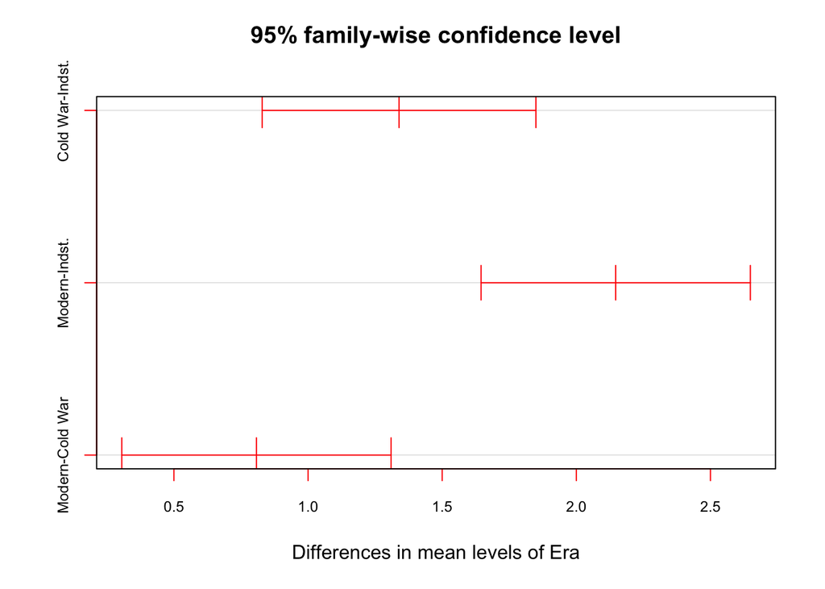

```r
plot(tukeyAoV, col="red", cex.axis=0.75)
```

### Outlier Check on Precipitation

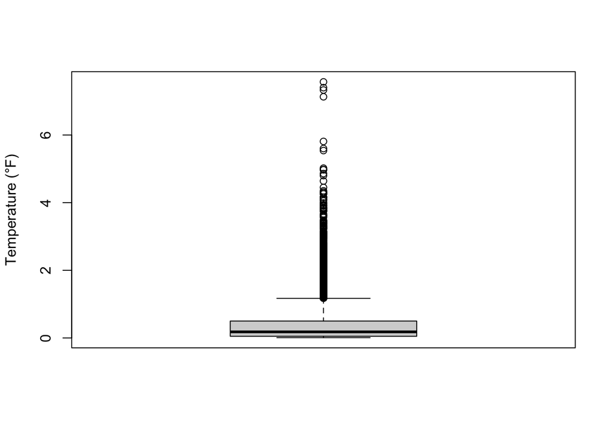

```r
library(ggrepel)
# extract PRCP outlier rows into df variable
# remove zeros
# group variable by decade, getting sum for each decade
prcp_no_zeros <- nyc_weather %>%
  filter(PRCP > 0.0 & !is.na(PRCP))
prcp_boxplot <- boxplot(prcp_no_zeros$PRCP, ylab = "Temperature (°F)")
```

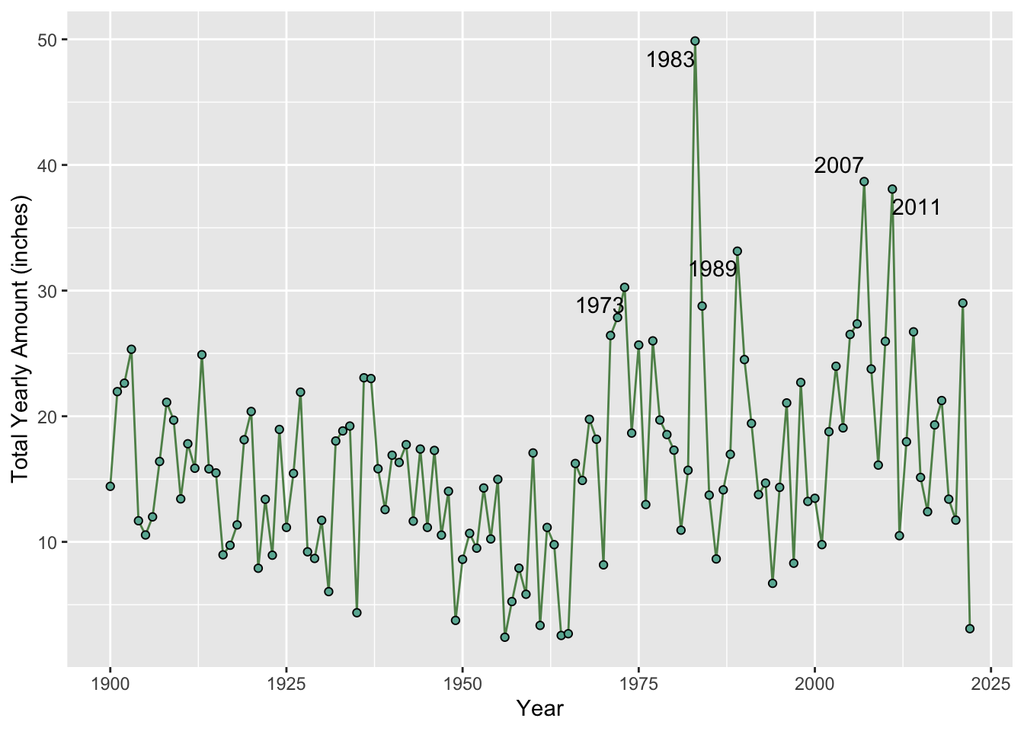

```r
prcp_outliers <- boxplot.stats(prcp_no_zeros$PRCP)$out
prcp_outliers.index <- which(prcp_no_zeros$PRCP %in% c(prcp_outliers))
prcp_outliers_df <- prcp_no_zeros[prcp_outliers.index, ]

prcp_outliers_df.yearly <- prcp_outliers_df %>%
  mutate(YEAR = lubridate::year(DATE)) %>%
  group_by(YEAR) %>%
  summarize(prcp_total = sum(PRCP, na.rm=T), count = n())

# show top 5 years
top_5_years.prcp_total <- prcp_outliers_df.yearly %>%
  slice_max(order_by = prcp_total, n = 5)

prcp_outliers_df.yearly %>%
  ggplot(aes(x=YEAR, y=prcp_total)) +
    geom_line(na.rm=TRUE, alpha=0.7, color="darkgreen") +
    geom_point(na.rm = TRUE, fill="#69b3a2", shape = 21) +
    geom_text_repel(aes(label=YEAR), data=top_5_years.prcp_total) +
    labs(x="Year", y="Total Yearly Amount (inches)") +
    scale_fill_brewer(palette="Spectral")
```

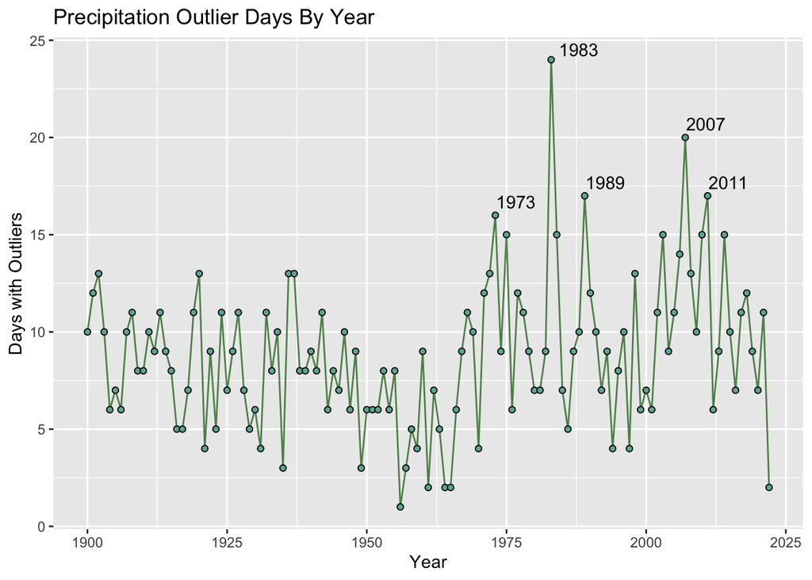

```r
top_5_years.count <- prcp_outliers_df.yearly %>%
  slice_max(order_by = count, n = 5)

prcp_outliers_df.yearly %>%
  ggplot(aes(x=YEAR, y=count)) +
    geom_line(na.rm=TRUE, alpha=0.7, color="darkgreen") +
    geom_point(na.rm = TRUE, fill="#69b3a2", shape = 21) +
    geom_text_repel(aes(label=YEAR), data=top_5_years.count) +
    labs(title="Precipitation Outlier Days By Year", x="Year", y="Days with Outliers")
```

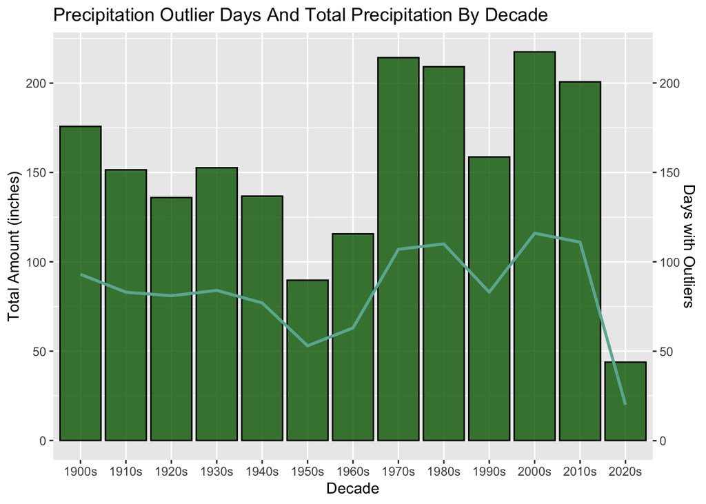

```r
# group into decades and create bar plot
prcp_outliers_df.decades <- prcp_outliers_df %>%
  mutate(decade = paste(floor(lubridate::year(DATE) / 10) * 10, "s", sep="")) %>%
  group_by(decade) %>%
  summarise(prcp_total = sum(PRCP, na.rm=T), count = n())

prcp_outliers_df.decades %>%
  ggplot(aes(group=1)) +
  geom_col(aes(x=decade, y=prcp_total), na.rm=TRUE, alpha=0.8, color="black", fill="darkgreen", position="identity") +
  geom_line(aes(x=decade, y=count), stat="identity", color="#69b3a2", size=1) +
  labs(title="Precipitation Outlier Days And Total Precipitation By Decade", x="Decade", y="Total Amount (inches)") +
  scale_y_continuous(sec.axis=sec_axis(~., name="Days with Outliers"))
```

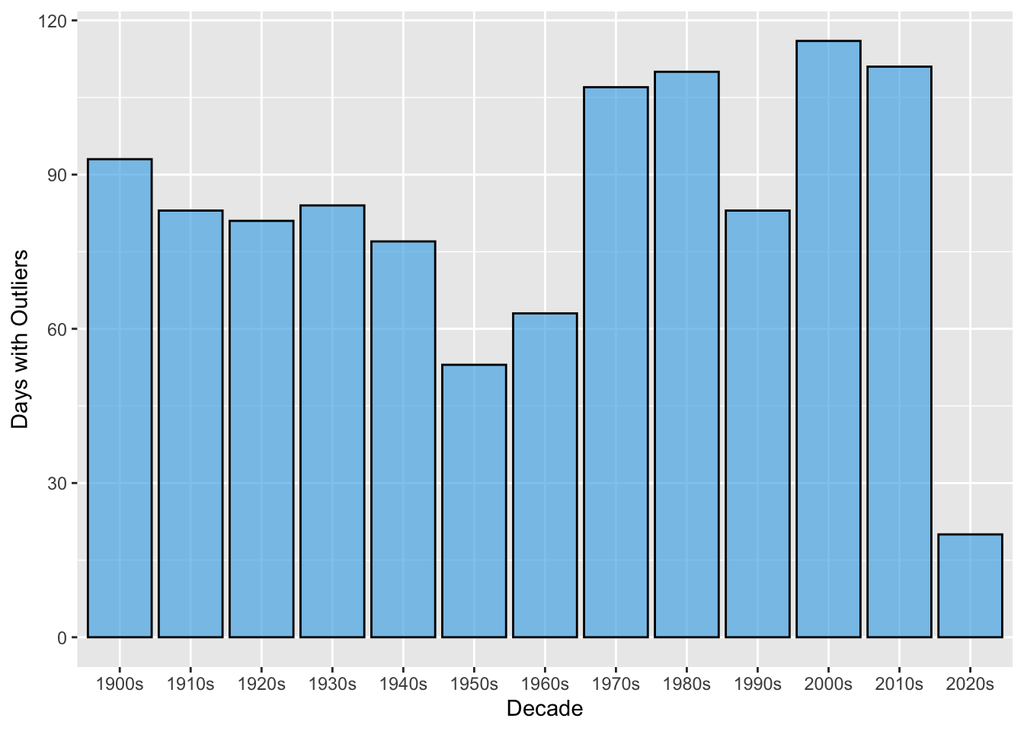

```r
prcp_outliers_df.decades %>%
  ggplot(aes(x=decade, y=count)) +
    geom_col(na.rm=TRUE, alpha=0.7, color="black", fill="#56B4E9", position="identity") +
    labs(x="Decade", y="Days with Outliers")
```

### Christmas Snow

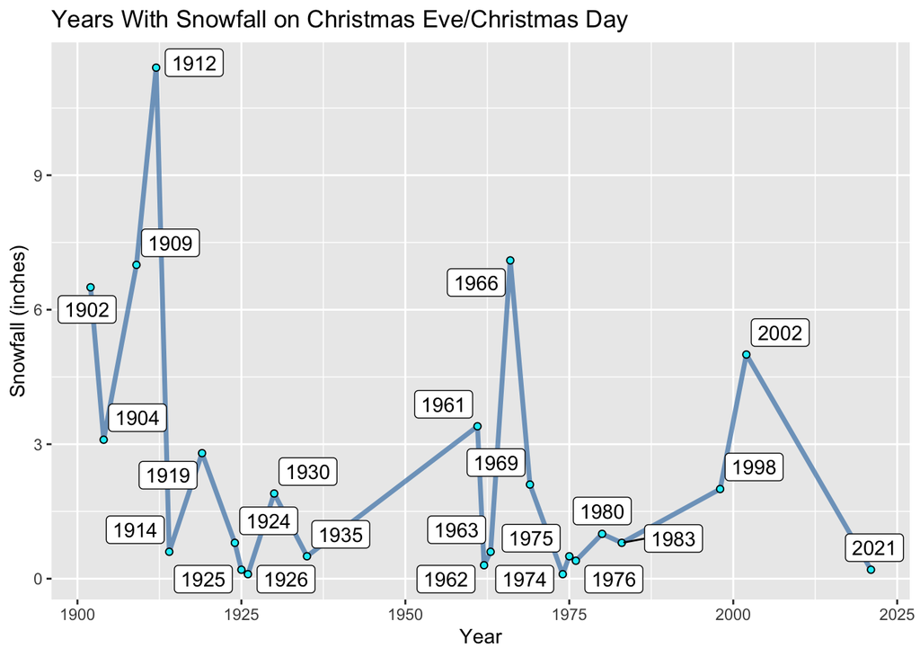

```r
# sum snowfall from 24-25th Dec
nyc_weather.christmas_snow <- nyc_weather %>%
  filter(lubridate::month(DATE) == 12, (lubridate::day(DATE) == 24 | lubridate::day(DATE) == 25)) %>%
  mutate(YEAR = lubridate::year(DATE)) %>%
  group_by(YEAR) %>%
  summarise(snowfall = sum(SNOW, na.rm = T))

# how many years has there been snow?
with_snow <- nyc_weather.christmas_snow %>%
  filter(snowfall > 0.0)

# highest snowfall year?
largest_snowfall <- nyc_weather.christmas_snow[which.max(nyc_weather.christmas_snow$snowfall), ]

# yearly plot for years it snowed
top_5_years.snowfall <- with_snow %>%
  slice_max(order_by = snowfall, n = 5)

with_snow %>%
  ggplot(aes(x=YEAR, y=snowfall)) +
    geom_line(na.rm=TRUE, alpha=0.7, color="steelblue", size=1.25) +
    geom_point(na.rm = TRUE, fill="#00edfa", shape = 21) +
    geom_label_repel(aes(label=YEAR), data=with_snow) +
    labs(title="Years With Snowfall on Christmas Eve/Christmas Day", x="Year", y="Snowfall (inches)")
```

The largest snowfall recorded on Christmas/Christmas Eve was in 1912 when it snowed 11.4 inches!!